# Parte 1

# Ejercicio 1

Utilizando el conjunto de datos “diamonds”, de la librería gcookbook, consigue las siguientes visualizaciones:

## Primera Visualizacion

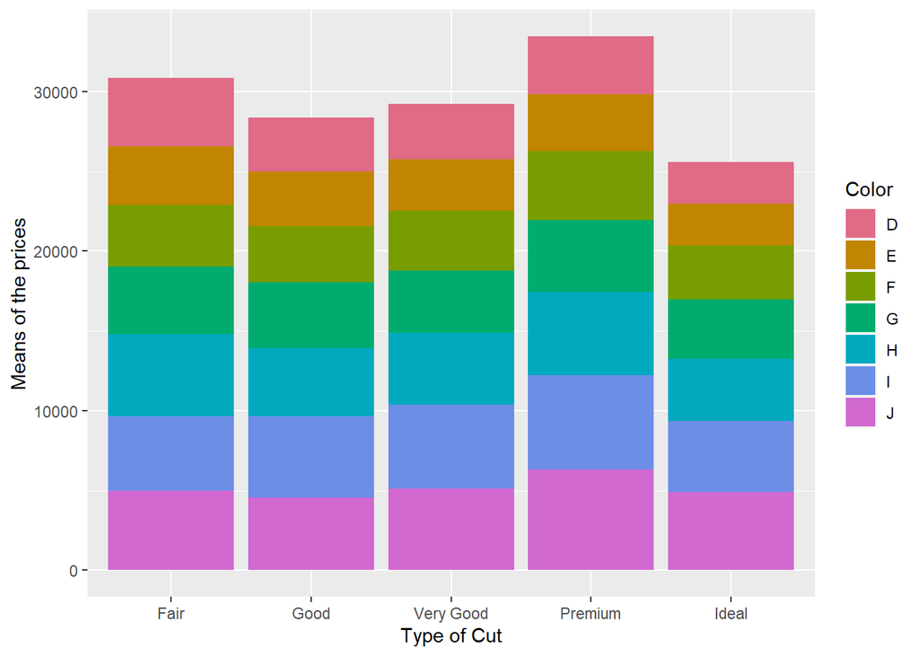

```r
library(gcookbook)
library(ggplot2)
library(dplyr)
library(paletteer)
df <- diamonds %>%
  rename(Color = color) %>%
  group_by(cut, Color) %>%
  summarise(price = mean(price))



ggplot(df, aes(x=cut, y =price, fill = Color)) +
  geom_col()+
  labs(x = "Type of Cut", y = "Means of the prices")+
  scale_fill_manual(values = paletteer_c("grDevices::Dark 3", 7))
```

## Segunda Visualizacion

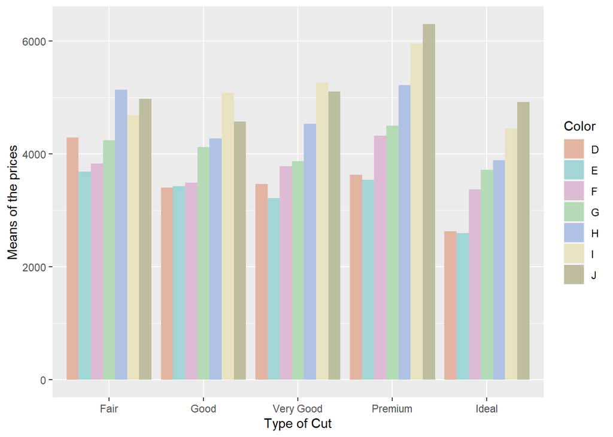

```r
ggplot(df, aes(x=cut, y =price, fill = Color)) +
  geom_col(position = "dodge")+
  labs(x = "Type of Cut", y = "Means of the prices")+
  scale_fill_manual(values = paletteer_dynamic("cartography::pastel.pal", 7))
```

# Ejercicio 2

El conjunto de datos Temperatures.csv que encontrarás en el Campus Virtual contiene información de la variación de las temperaturas con respecto a la media (variable Variation) entre los años 1900 y 2000 (variable Year).

Además, la variable Positive indica “True” si la variación fue positiva y “False” si la variación fue negativa.

Aparece otra variable, conf.level95, con la información del intervalo de confianza al 95%.

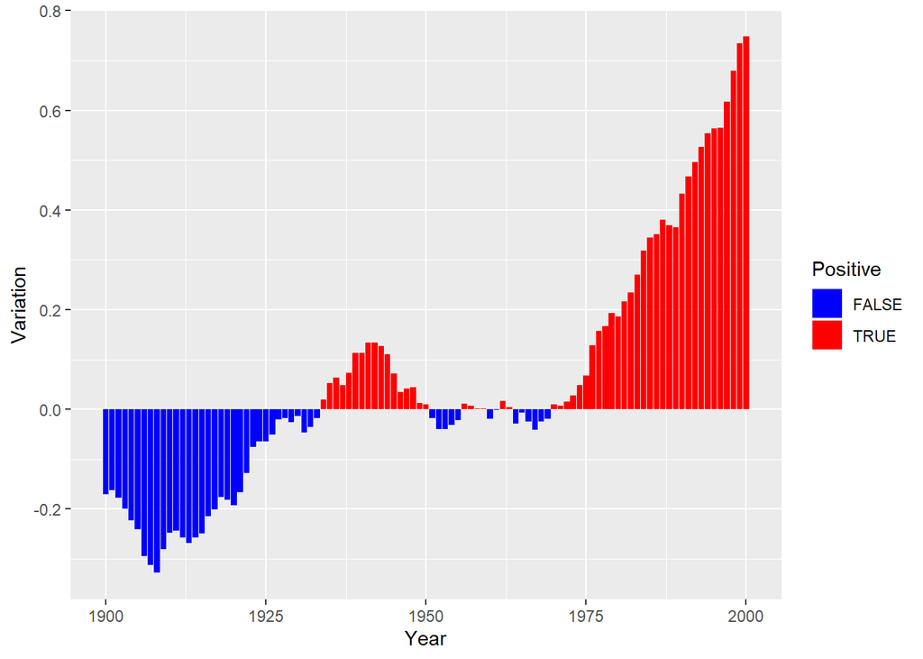

```r
data <- read.csv("Temperatures.csv",header = TRUE,sep =",")


ggplot(data, aes(x=Year, y = Variation, fill = Positive)) +
  geom_col() +
  scale_fill_manual(values = c("blue","red"))
```

# Ejercicio 3

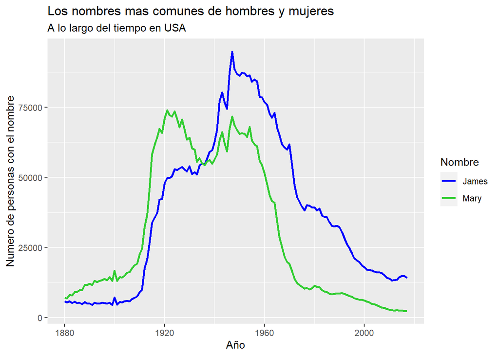

```r
library(babynames)
library(dplyr)
library(ggplot2)
data <- babynames

datam <- data %>%
  filter(sex == "M") %>%
  arrange(desc(n))


datam <- datam %>%
  filter(name == "James") %>%
  select(year,quantity_men= n ) %>%
  arrange(desc(year))



dataf <- data %>%
  filter(sex == "F") %>%
  arrange(desc(n))

dataf <- dataf %>%
  filter(name == "Mary") %>%
  select(year,quantity_wmen= n ) %>%
  arrange(desc(year))



df <- data.frame(dataf$year,datam$quantity_men,dataf$quantity_wmen)
df <- df %>%
  select(year = dataf.year, men=datam.quantity_men, women=dataf.quantity_wmen)

ggplot(df, aes(x=year, y=men, color="James")) +
  geom_line(size=1) +
  geom_line(aes(x=year, y=women, color="Mary"), linetype=1, size=1) +
  xlab("Año") +
  ylab("Numero de personas con el nombre") +
  labs(color="Nombre") +
  scale_color_manual(values=c("James"="blue", "Mary"="limegreen"))+
  ggtitle("Los nombres mas comunes de hombres y mujeres", subtitle = "A lo largo del tiempo en USA")
```

# Ejercicio 4

```r
library(readr)
library(tidyverse)
library(ggplot2)
library(gcookbook)
library(data.table)
datos <- fread("EsperanzaVidayNatalidadCA.csv", encoding = "Latin-1")

datos$EsperanzaVida <- gsub(",", ".", datos$EsperanzaVida)
datos$EsperanzaVida <- as.numeric(datos$EsperanzaVida)
datos$Natalidad <- gsub(",", ".", datos$Natalidad)
datos$Natalidad <- as.numeric(datos$Natalidad)
```

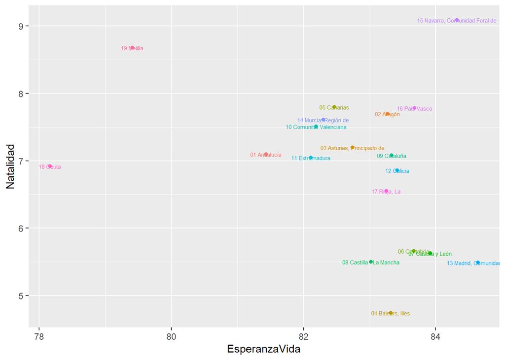

```r
datos <- datos[-c(20), ]
ggplot(datos, aes(x = EsperanzaVida, y = Natalidad, color = ComunidadesAutonomas)) +
  geom_point() +
  theme(legend.position = "none") +
  geom_text(aes(label = ComunidadesAutonomas), size=2)
```

# Ejercicio 5

Grafico libre

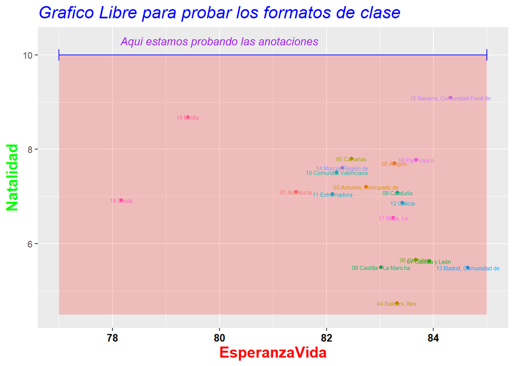

```r
datos <- datos[-c(20), ]
ggplot(datos, aes(x = EsperanzaVida, y = Natalidad, color = ComunidadesAutonomas)) +
  geom_point() +
  ggtitle("Grafico Libre para probar los formatos de clase") +
  theme(legend.position = "none",
        plot.title = element_text(
        face = "italic",
        size = 17,
        color = "blue"),
        axis.title.x = element_text(
        face = "bold",
        size = 15,
        color = "red"),
        axis.title.y = element_text(
        face = "bold",
        size = 15,
        color = "green"),
        axis.text.x = element_text(
        face = "bold",
        size = 10,
        color = "black")) +
  annotate("rect",
         xmin = 77,xmax=85,
         ymin = 4.5, ymax=10,
         fill="red",
         alpha=.2) +
   annotate("segment", x = 77, xend = 85, y =10, yend = 10,
           arrow = arrow(ends = "both", angle = 90, length = unit(.2,"cm")),color = "blue")+
  annotate(geom = "text", x = 80, y = 10.3, label = "Aqui estamos probando las anotaciones", color = "purple", fontsize =5, fontface= "italic")+
  geom_text(aes(label = ComunidadesAutonomas), size=2)
```

```r
millonarios <- read.csv("Forbes Billionaires.csv", sep = ",")

millonarios <- millonarios %>%
  top_n(20, Networth)
```

Grafico de los 20 mas ricos segun Forbes, edad vs patrimonio.

[figure not shown]

```r
  ggplot(millonarios, aes(x = Age, y = Networth, color = Name)) +
  geom_point() +
  ggtitle("Los 20 mas ricos segun \nForbes en 2022, edad vs patrimonio") +
  theme_light() +
  theme(legend.position = "none",
        plot.title = element_text(
        face = "bold",
        size = 25,
        color = "blue"),
        axis.title.x = element_text(
        face = "bold",
        size = 15,
        color = "black"),
        axis.title.y = element_text(
        face = "bold",
        size = 15,
        color = "black"),
        axis.text.x = element_text(
        face = "bold",
        size = 10,
        color = "black")) +
  geom_text(aes(label = Name), size=2, vjust = -.8)+
  annotate("rect",
         xmin = 55,xmax=95,
         ymin = 40, ymax=190,
         fill="blue",
         alpha=.2)+
  annotate("segment",
           x = 55,
           xend = 50,
           y = 218,
           yend = 218,
           colour = "red",
           size = 1,
           arrow = arrow())+
  annotate(geom = "text", x = 70, y = 218, label = "El mas rico, se encuentra en los 50...", color = "red", fontsize =5, fontface= "italic")+
  annotate("segment", x = 55, xend = 95, y =190, yend = 190,
           arrow = arrow(ends = "both", angle = 90, length = unit(.2,"cm")),color = "blue")+
  annotate(geom = "text", x = 77, y = 200, label = "Los ricos mayores de 50", color = "blue", fontsize =5, fontface= "italic")+
  annotate("rect",
         xmin = 30,xmax=50,
         ymin = 50, ymax=125,
         fill="green",
         alpha=.2)+
  annotate(geom = "text", x = 40, y = 130, label = "Ricos menores de 50", color = "limegreen", fontsize =5, fontface= "italic")
```